# Analyse géospatiale de l’implémentation de Quick en France

Kezhan SHI

02 Novembre 2015

# 1 Introduction

“Je préfère le McDo!” “OK, tu vas au McDo en face. Nous, on va chez Quick. Et on se retrouve après pour aller au parc.” Là où il y a un Quick, on trouve sûrement un McDonald’s pas loin. On a souvent cette impression par rapport à l’implantation de Quick. Afin de vérifier si c’est vrai, j’ai fait quelques analyses par rapport aux emplacements de ces deux enseignes.

# 2 Géolocalisation des commerces

Afin de comparer l’implémentation de plusieurs commerces, on peut visualiser sur le plan suivant les restaurants Quick, McDonald’s, Hipoputamus, et les magasins La Halle.

```r
load("geodata.RData")

m=leaflet() %>% addTiles() %>%
  addCircleMarkers(lng=qf$lng, lat=qf$lat,radius=5,color = "red",
                   stroke = FALSE, fillOpacity = 0.9,group="Quick",popup=qf$name) %>%
  addCircleMarkers(lng=mc$lon, lat=mc$lat,radius=5,color = "green",
                   stroke = FALSE, fillOpacity = 0.9,group="McDonald's",popup=mc$noms)%>%
  addCircleMarkers(lng=hippo$lon, lat=hippo$lat,radius=5,color = "purple",
                   stroke = FALSE, fillOpacity = 0.9,group="Hippopotamus",popup=hippo$cp)%>%
  addCircleMarkers(lng=halle$lng, lat=halle$lat,radius=5,color = "black",
                   stroke = FALSE, fillOpacity = 0.9,group="LaHalle",popup=halle$nom)%>%
  addLayersControl(
    overlayGroups = c("Quick", "McDonald's","Hippopotamus","LaHalle"),
    options = layersControlOptions(collapsed = FALSE)
  )%>%
  addLegend(colors = c("red","green","purple","black"),
            labels = c("Quick","McDonald's","Hippopotamus","Lahalle"), opacity = 1)
m
```

[interactive chart not shown]

## 2.1 Taux de concentration des enseignes

Pour chaque point de vente, on peut calculer la distance du proche point de vente, ensuite tracer la distribution.

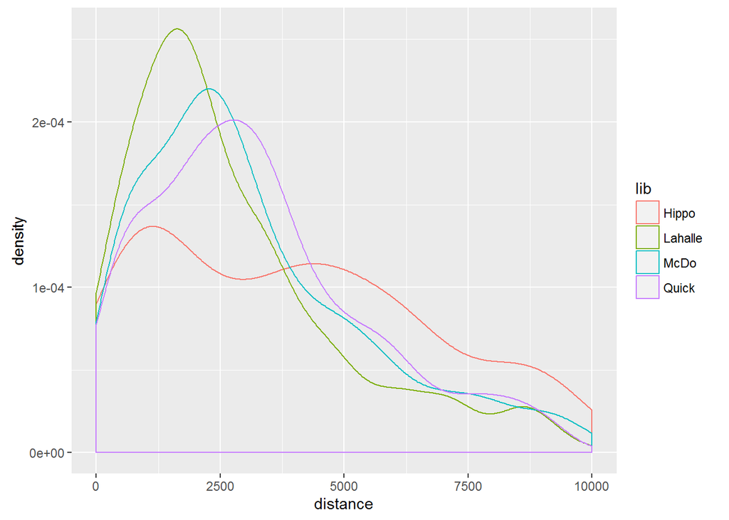

```r
dis <- function(long1, lat1, long2, lat2) {
  long1=long1*pi/180
  lat1=lat1*pi/180
  long2=long2*pi/180
  lat2=lat2*pi/180
  R <- 6371000 # Earth mean radius [km]
  delta.long <- (long2 - long1)
  delta.lat <- (lat2 - lat1)
  a <- sin(delta.lat/2)^2 + cos(lat1) * cos(lat2) * sin(delta.long/2)^2
  c <- 2 * asin(sqrt(a))
  d = R * c
  return(d) # Distance in km
}


dqq=rep(0,nrow(qf))
for (i in 1:nrow(qf)){
  dqq[i]=sort(dis(qf[i,]$lng,qf[i,]$lat,qf$lng,qf$lat))[2]
}

dmm=rep(0,nrow(mc))
for (i in 1:nrow(mc)){
  d=sort(dis(mc[i,]$lon,mc[i,]$lat,mc$lon,mc$lat))
  d=d[d>0]
  dmm[i]=d[1]
}

dhh=rep(0,nrow(hippo))
for (i in 1:nrow(hippo)){
  dhh[i]=sort(dis(hippo[i,]$lon,hippo[i,]$lat,hippo$lon,hippo$lat))[2]
}

dhh2=rep(0,nrow(halle))
for (i in 1:nrow(halle)){
  d=sort(dis(halle[i,]$lng,halle[i,]$lat,halle$lng,halle$lat))
  d=d[d>0]
  dhh2[i]=d[1]
}


ddist=data.table(distance=c(dqq,dmm,dhh,dhh2),
                 lib=c(rep("Quick",length(dqq)),
                       rep("McDo",length(dmm)),
                       rep("Hippo",length(dhh)),
                       rep("Lahalle",length(dhh2))))

ggplot(ddist, aes(distance,colour=lib)) +
  geom_density()+xlim(0,10000)
```

On voit que les Hippopotamus sont plus dispersés, et les Lahalle sont plus concentrés. Lahalle est plus concentré que McDonald’s, cela est sans doute lié au fait qu’un nombre important de McDonald’s sont situés à côté des autoroutes.

Les deux enseignes Quick et McDonald’s ont sensiblement le même “taux de concentration”.

```r
median(dqq)
```

```
## [1] 3639.452
```

```r
median(dmm,na.rm = T)
```

```
## [1] 3748.69
```

```r
median(dhh,na.rm = T)
```

```
## [1] 5658.204
```

```r
median(dhh2,na.rm = T)
```

```
## [1] 2646.085
```

## 2.2 Distance Quick-McDonald’s

Pour savoir à quel point les Quick sont implantés à proximité des McDonald’s, j’ai calculé la distance du McDonald’s le plus proche pour chacun des Quick. Ainsi on peut ensuite tracer des distributions de ces distances minimales.

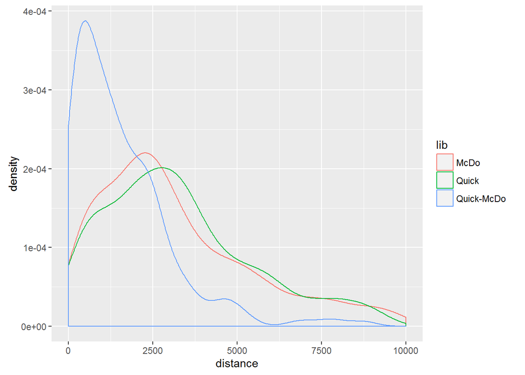

```r
dqm=rep(0,nrow(qf))
for (i in 1:nrow(qf)){
  dqm[i]=min(dis(qf[i,]$lng,qf[i,]$lat,mc$lon,mc$lat),na.rm = T)
}


ddist=data.table(distance=c(dqq,dqm,dmm),
                 lib=c(rep("Quick",length(dqq)),
                       rep("Quick-McDo",length(dqm)),
                       rep("McDo",length(dmm))))
ggplot(ddist, aes(distance,colour=lib)) +
  geom_density()+xlim(0,10000)
```

# 3 Comptage dans une zone

## 3.1 Concentration de McDonald’s

On peut découper la France selon un maillage, et regarder les zones où le nombre de McDonald’s dépasse 2.

```r
maille_mc=pts[pts$freqmc>2,]
pal <- colorNumeric(
  palette = "Spectral",
  domain = maille_mc$freqmc
)
m=leaflet(data=maille_mc) %>%
  addTiles() %>%
  addRectangles(
    lng1=~x-pas/2, lat1=~y-pas/2,
    lng2=~x+pas/2, lat2=~y+pas/2,
    color=~pal(freqmc),
    popup=~as.character(freqmc))%>%
  addMarkers(lng=~x, lat=~y,popup=~as.character(freqmc))
m
```

[interactive chart not shown]

## 3.2 Zones “inoccupées” par Quick

Dans un quartier animé, on n’a pas un seul McDonald’s, mais plusieurs. Ainsi, je me suis demandé s’il y a des quartiers où il y a plusieurs McDonald’s, mais il n’y a pas de Quick.

```r
manque_quick=pts[pts$freqmc>2,]
manque_quick=manque_quick[manque_quick$freqq==0,]
nrow(manque_quick)
```

```
## [1] 8
```

```r
pal <- colorNumeric(
  palette = "Spectral",
  domain = manque_quick$freqmc
)

m=leaflet(data=manque_quick) %>%
  addTiles() %>%
  addRectangles(
    lng1=~x-pas/2, lat1=~y-pas/2,
    lng2=~x+pas/2, lat2=~y+pas/2,
    color=~pal(freqmc),
    popup=~as.character(freqmc))%>%
  addMarkers(lng=~x, lat=~y,popup=~as.character(freqmc))
m
```

[interactive chart not shown]

# 4 Conclusion

“Un article sur Quick et McDonald’s ? Je pensais que tu travaillais dans l’assurance…” “Si on remplace les restaurants par les contrats d’assurance habitation, des études très intéressantes pourront être faites !… Mais là, je crois que j’ai trouvé l’opportunité de rêve: on va créer une franchise Quick à proximité du parc de la Villette. Il y a 5 McDonald’s et pas de Quick!”

Copyright © 2016 Blog de Kezhan Shi